# lab3-parte1-Rmarkdown

Bruna Barbosa

February 15, 2017

## LAB03

**Os dados capturam o histórico de alunos do primeiro período (feras) de 2000 a 2015. Os campos são os seguintes:**

MAT_ALU_MATRICULA: Matrrícula aluno (anonimizado)  
MAT_TUR_DIS_DISCIPLINA: Código Disciplina  
disciplina: Nome Disciplina  
MAT_TUR_ANO: Ano da matrícula  
MAT_MEDIA_FINAL: Média obtida na disciplina  
EVADIU: Variável-alvo que indica se o aluno evadiu ou não ao término do período.

> Sobre a Parte 1

Nessa primeira etapa o objetivo é entender os dados e pensar em atributos que podem ajudar na classificação. Lembre-se que grande parte do sucesso de uma tarefa de predição está na escolha de bons atributos.

> Gere uma visualização que mostre em que ano houve mais evasões;

```r
#imports
library(readr)
library(dplyr)
library(ggplot2)

treino_classificacao <- read_csv("treino_classificacao.csv")
```

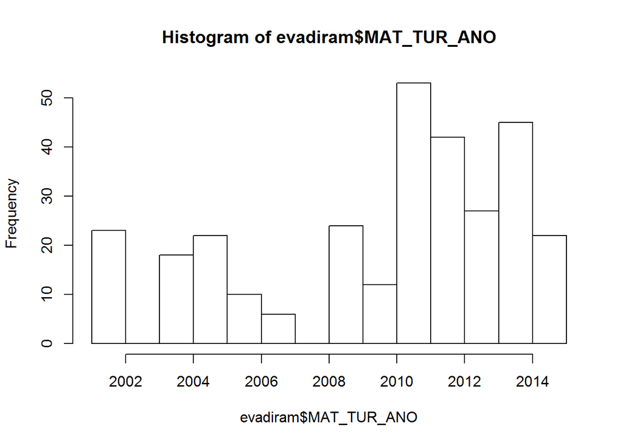

```r
evadiram <- treino_classificacao[treino_classificacao$EVADIU == TRUE, ]
naoEvadiram <- treino_classificacao[treino_classificacao$EVADIU == FALSE, ]

#Alunos que evadiram por ano -- ano que mais houve evasao de alunos: 2011
hist(evadiram$MAT_TUR_ANO)
```

O ano em que mais alunos evadiram foi o ano 2011.  
Uma possivel explicação é que no ano de 2011 a UFCG adatou o enem como metodo de entrada para novos aluno. Acredito que esse novo metodo de entrada nao é tao rigoroso quanto o metodo antigo.

> Gere uma visualização da distribuição das classes (número de instâncias de cada classe nos dados);

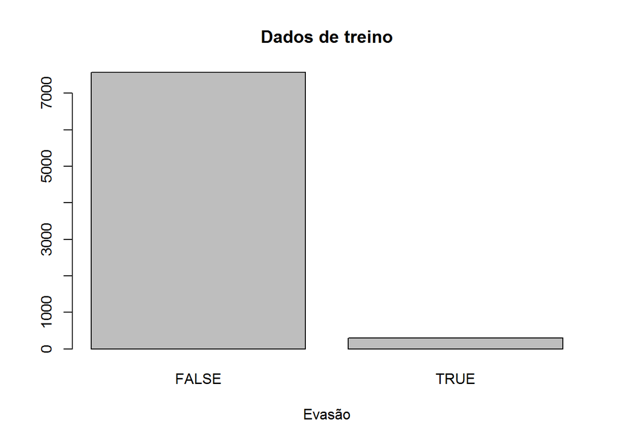

```r
# Simple Bar Plot
counts <- table(treino_classificacao$EVADIU)
barplot(counts, main="Dados de treino",
        xlab="Evasão")
```

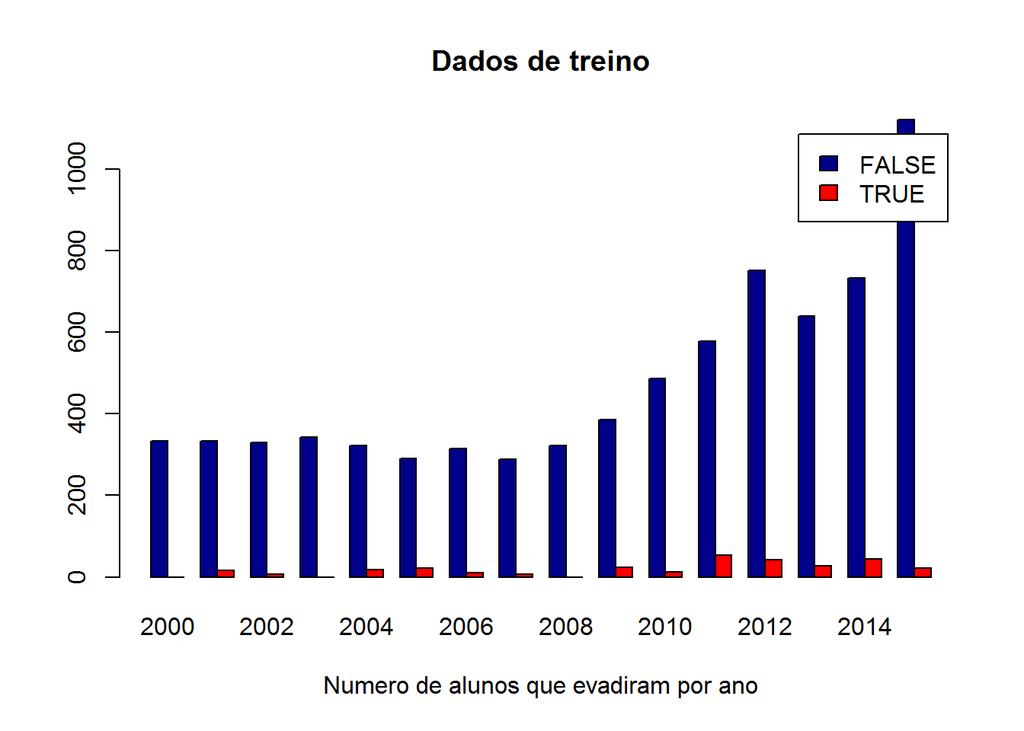

```r
#Confirma o que o histograma mostrou, mais pessoas evadiram em 2011
counts <- table(treino_classificacao$EVADIU, treino_classificacao$MAT_TUR_ANO)
barplot(counts, main="Dados de treino",
        xlab="Numero de alunos que evadiram por ano", col=c("darkblue","red"),
        legend = rownames(counts), beside=TRUE)
```

O segundo grafico de barras reforça que 2011 foi o ano que mais alunos evadiram.

> Há desbalanceamento das classes (isto é, uma classe tem muito mais instâncias que outra)? Em que proporção? Quais efeitos colaterais o desbalancemanento de classes pode causar no classificador?

```r
prop.table(table(treino_classificacao$EVADIU))
```

```
##
##      FALSE       TRUE
## 0.96139192 0.03860808
```

Há desbalaceamento entre as classes, a classe dos alunos que nao evadiram tem aproximadamente 96% das instâncias.

O desbalanceamento entre classes pode causar prejuizo na acuracia do algoritmo. O classificador tende a ficar enviesado para a classe majoritaria.  
O algoritmo assume que os dados sao balanceados entre as classes e atribuem o mesmo peso para predições erradas. No nosso caso, prever que o aluno nao vai evadir e errar essa predição tem um peso maior, pois nao foi possivel tentar convencer esse aluno a mudar sua decisão.

> Crie pelo menos um atributo novo, que não seja a média da disciplina, que você acha que pode ajudar na classificação.

##### Descreva-o e diga por que você acha que pode ser uma boa ideia usá-lo;

Um novo atributo que vou considerar nesse LAB é se o aluno esta cursando uma disciplina pela terceira vez. Alunos que estao cursando uma disciplina pela terceira vez tem grande dificuldade em concluir a disciplina e podem desisitir da graduação.

##### Compare visualmente a distribuição desse atributo em cada classe (e.g. usando boxplots): elas parecem ser diferentes? O que ajuda mais o classificador, atributos que tem distribuições de valores diferentes entre as classes ou distribuições parecidas? Por que?

Atributos que tem distribuições diferentes entre as classes sao mais efetivos para ajudar o classificador a fazer uma decisão. A falta ou presença daquele atributo na instancia vai influenciar na probabilidade de como a instancia vai ser classificada.

Exemplo de um banco: Pagadores que ganham mais de 50 000/mes provavelmente são bons pagadores.  
No caso, o atributo é se o cliente tem um salario > 50 000 (altoSalario).